# Graficos de mosaico

30/8/2021

## Graficos de mosaico

Otra forma de representar las tablas multidimensionales de frecuencia es con **gráfcos de mosaico**. Se obtienen sustituyendo cada entrada de la tabla de frecuencias por una región rectangular de área proporcional a su valor.

En concreto, para obtener el gráfico de mosaico de una tabla bidimensional, se parte de un cuadrado de lado 1, primero se divide en barras verticales de amplitudes iguales a las frecuencias relativas de una variable, y luego cada barra se divide, a lo alto, en regiones de alturas proporcionales a las frecuencias relativas marginales de cada nivel de la otra variable, dentro del nivel correspondiente a la misma variable.

En R se puede obtener con la función `mosaicplot`. También se puede aplicar a matrices.

## Graficos de mosaico

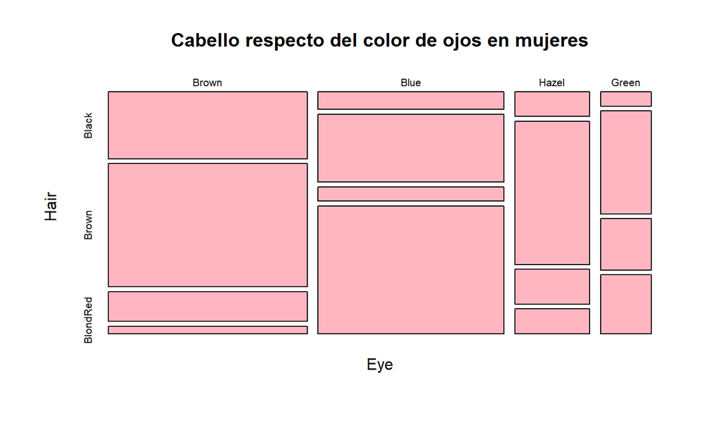

## Grafico tridimensional de mosaico

Primero se divide el cuadrado en barras verticales de amplitudes iguales a las frecuencias relativas de una variable.

Luego cada barra se divide, a lo alto, en regiones de alturas proporcionales a las frecuencias relativas marginales de cada nivel de una segunda variable, dentro del nivel correspondiente de la primera variable.

Finalmente, cada sector se vuelve a dividir a lo ancho en regiones de amplitudes proporcionales a las frecuencias relativas marginales de cada nivel de la tercera variable dentro de la combinación correspondiente de niveles de las otras dos.

## Grafico de mosaico tridimensional

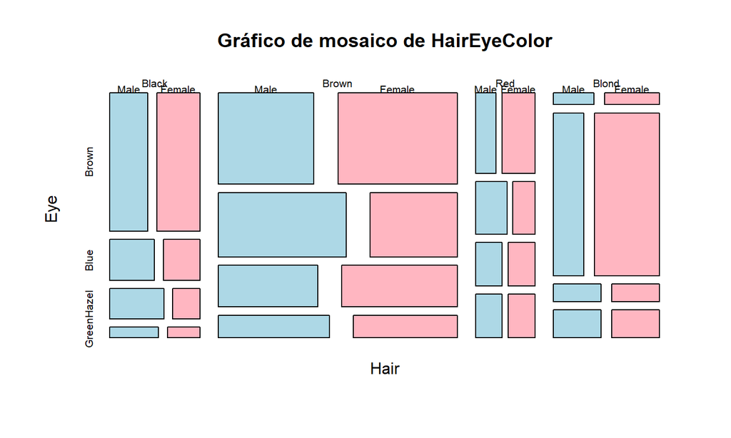

## Otros gráficos

Además de los parámetros usuales, la función **plot** admite algunos parámetros específicos cuando se usa para producir el gráfico de mosaico de una tabla. Estos parámetros se pueden consultar con **help(mosaicplot)**.

Los paquetes **vcd** y **vcdExtra** incluyen otras funciones que producen representaciones gráficas para tablas tridimensionales.

- La función **cotabplot** de **vcd** produce un diagrama de mosaico para cada nivel de la variable.
- La función **mosaic3d** de **vcdExtra** produce un diagrama de mosaico tridimensional en una ventana para gráficos 3D interactivos.

## VCD

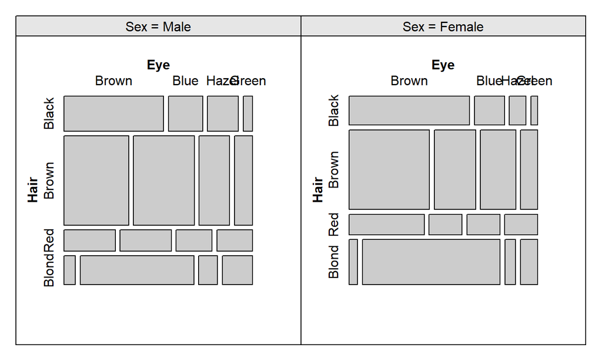